# Correlation matrix

# create gene annotations with start coordinate of each gene

# subset to contain only genes which are included in our peak2gene matrix

gene_anno <- gene_anno %>% as.data.frame() %>% filter(name %in% rownames(p2g_mat)) %>% mutate(strand = ifelse(strand == 1, “+”, “-”)) %>% mutate(start_coord = ifelse(strand == “+”, start, end)) %>% rename(gene = name) %>% GRanges()

# subset atac granges & get middle of each peak

pos_atac_granges <- atac_granges %>% as.data.frame() %>% group_by(seqnames) %>% mutate(idx = seq_along(seqnames)) %>% ungroup %>% tidyr::unite(chr_idx, seqnames, idx, remove = FALSE, sep = “_“) %>% filter(chr_idx %in% colnames(p2g_mat)) %>% mutate(middle = start + 300) %>% GRanges()

#TODO: Filter for genes! p2g_filt <- p2g %>% filter(gene %in% rownames(hvg_p2g))

# combine the three dataframesp

p2g_join <- left_join(p2g_filt, as.data.frame(pos_atac_granges), by = “chr_idx”) p2g_join <- left_join(p2g_join, as.data.frame(gene_anno), by = “gene”, suffix = c(“.atac”, “.rna”))

# compute distance and distance weights

p2g_join <- p2g_join %>% mutate(distance = abs(start_coord - middle)) %>% mutate(distance_weight = eval(parse(text=geneModel)))

p1 <- p2g_join %>% ggplot() + geom_histogram(aes(x = distance), bins = 100) + labs(title = “Distance”, x = “distance”) + geom_vline(xintercept = 5000, color = “red”)

p2 <- p2g_join %>% ggplot() + geom_histogram(aes(x = (distance_weight)), bins = 100) + scale_y_log10() + labs(titel = “Distance Weights”, x = “distance weights”)

cowplot::plot_grid(p1, p2,p3, ncol = 1)

[output not shown]

# Compute gene activity scores with distance weight and restriction to gene window

```r
p2g_mat <- hvg_p2g



atac_granges <- metadata(p2g_original)[[1]]
#rna_granges <- metadata(p2g_original)[[2]]
gene_expr <- getMatrixFromProject(proj, useMatrix = "GeneExpressionMatrix")
gene_anno <- rowData(gene_expr)

# create gene annotations with start coordinate of each gene
# subset to contain only genes which are included in our peak2gene matrix
gene_anno <- gene_anno %>% as.data.frame() %>%
  filter(name %in% rownames(p2g_mat)) %>%
  mutate(strand = ifelse(strand == 1, "+", "-")) %>%
  mutate(start_coord = ifelse(strand == "+", start, end)) %>%
  rename(gene = name) %>%
  GRanges()

# subset atac granges & get middle of each peak
pos_atac_granges <- atac_granges  %>%
  as.data.frame() %>%
  group_by(seqnames) %>%
  mutate(idx = seq_along(seqnames)) %>%
  ungroup %>%
  tidyr::unite(chr_idx, seqnames, idx, remove = FALSE, sep = "_") %>%
  filter(chr_idx %in% colnames(p2g_mat)) %>%
  mutate(middle = start + 300) %>%
  GRanges()

#TODO: Filter for genes!
p2g_filt <- p2g %>% filter(gene %in% rownames(p2g_mat))


# combine the three dataframes
p2g_join <- left_join(p2g_filt, as.data.frame(pos_atac_granges), by = "chr_idx")
p2g_join <- left_join(p2g_join, as.data.frame(gene_anno),
                      by = "gene", suffix = c(".atac", ".rna"))


# Compute the distance between the TSS and the middle of the peak
p2g_join <- p2g_join %>%
  mutate(distance = abs(start_coord - middle))
```

### Effect of using different distance decay rates

How does the distance weight distribution change with different decay rates?

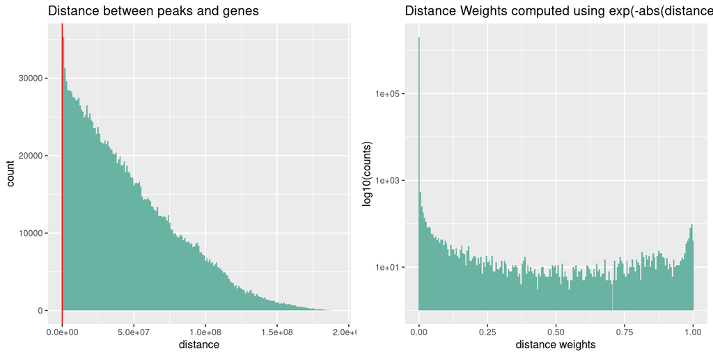

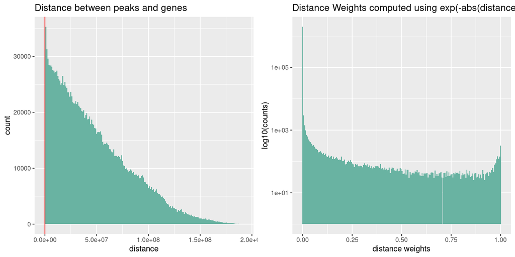

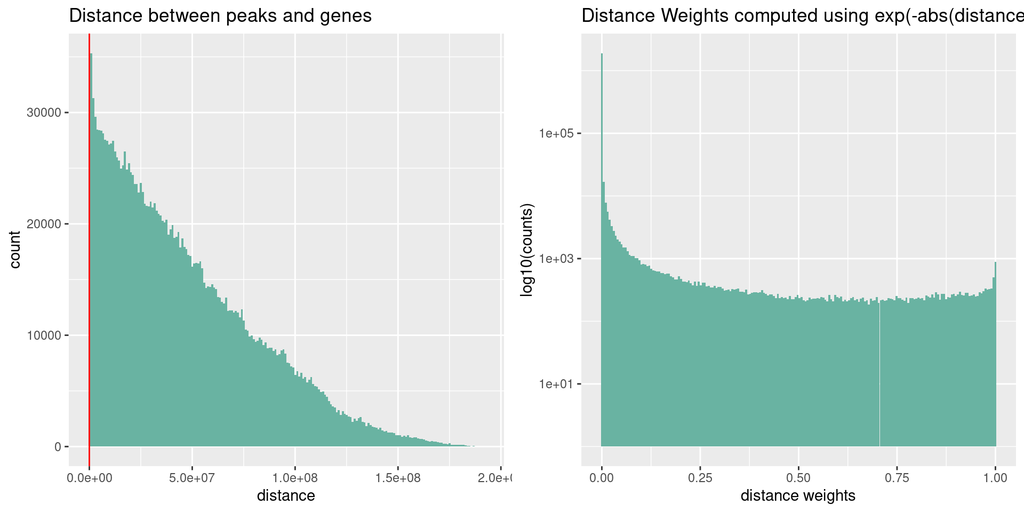

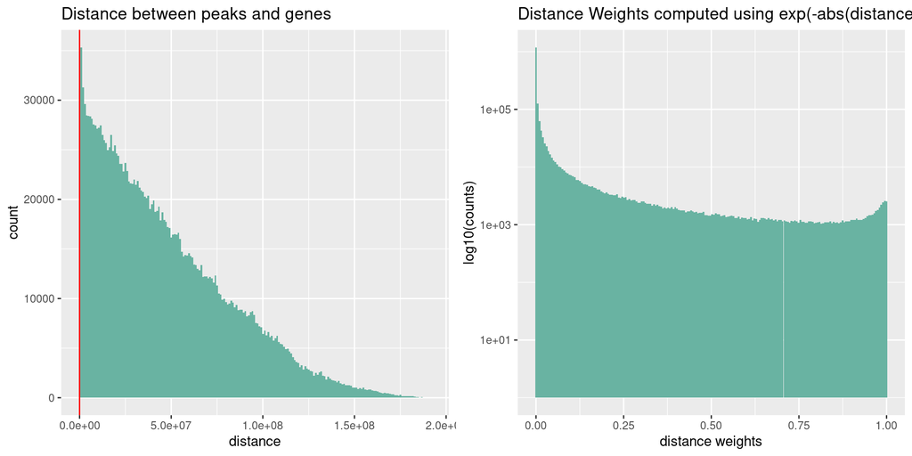

```r
model_list <- c("exp(-abs(distance)/5000)", "exp(-abs(distance)/50000)",
                "exp(-abs(distance)/500000)", "exp(-abs(distance)/5000000)")

for (model in model_list){
# compute distance and distance weights
  p2g_join <- p2g_join %>%
    mutate(distance = abs(start_coord - middle)) %>%
    mutate(distance_weight = eval(parse(text=model)))

  p1 <- p2g_join %>% ggplot() +
    geom_histogram(aes(x = distance), bins = 200, fill="#69b3a2") +
    labs(title = "Distance between peaks and genes", x = "distance") +
    geom_vline(xintercept  = 5000, color = "red")

  p2 <- p2g_join %>% ggplot() +
    geom_histogram(aes(x = (distance_weight)), bins = 200, fill="#69b3a2") +
    scale_y_log10() +
    labs(title = paste0("Distance Weights computed using ", model),
         x = "distance weights", y = "log10(counts)")

  print(cowplot::plot_grid(p1, p2, ncol = 2))

}
```

```r
  # Relationship between distance and correlation value
# p3 <- p2g_join %>% ggplot() +
#   geom_point(aes(x = Correlation, y = distance)) +
#   labs(title = "Distance vs. correlation between peaks and genes",
#        x = "Correlation between peak and gene",
#        y = "Distance between peak and gene")
#
#
# p4 <- p2g_join %>% ggplot() +
#   geom_point(aes(x = Correlation, y = distance_weight)) +
#   labs(title = "Distance vs. correlation between peaks and genes",
#        x = "Correlation between peak and gene",
#        y = "Distance weights between peak and gene")


#cowplot::plot_grid(p1, p2, ncol = 1)
```

### Relationship between distance and correlation values

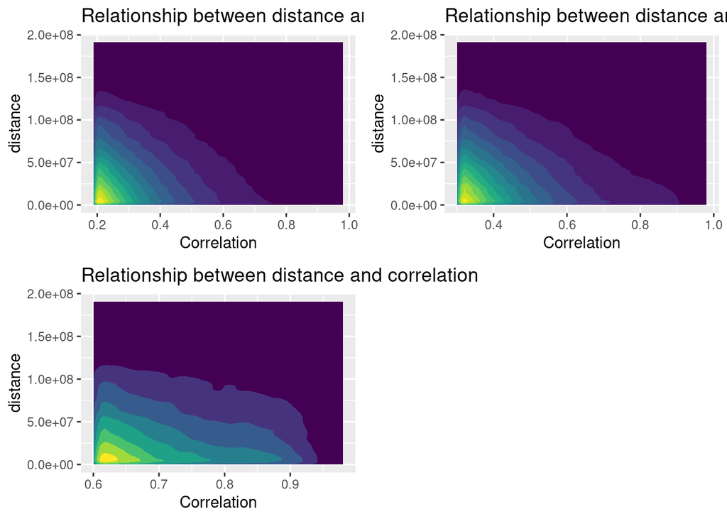

```r
# Olot relationship between distance and correlation as density plots
p1 <- p2g_join %>% ggplot() +
  geom_density_2d_filled(aes(x = Correlation, y = distance)) +
  theme(legend.position = "None") +
  labs(title = "Relationship between distance and correlation")

p2 <- p2g_join %>%
  filter(Correlation > 0.3) %>%
  ggplot() +
  geom_density_2d_filled(aes(x = Correlation, y = distance)) +
  theme(legend.position = "None") +
  labs(title = "Relationship between distance and correlation")

p3 <- p2g_join %>%
  filter(Correlation > 0.6) %>%
  ggplot() +
  geom_density_2d_filled(aes(x = Correlation, y = distance)) +
  theme(legend.position = "None") +
  labs(title = "Relationship between distance and correlation")

cowplot::plot_grid(p1, p2, p3, ncol = 2)
```

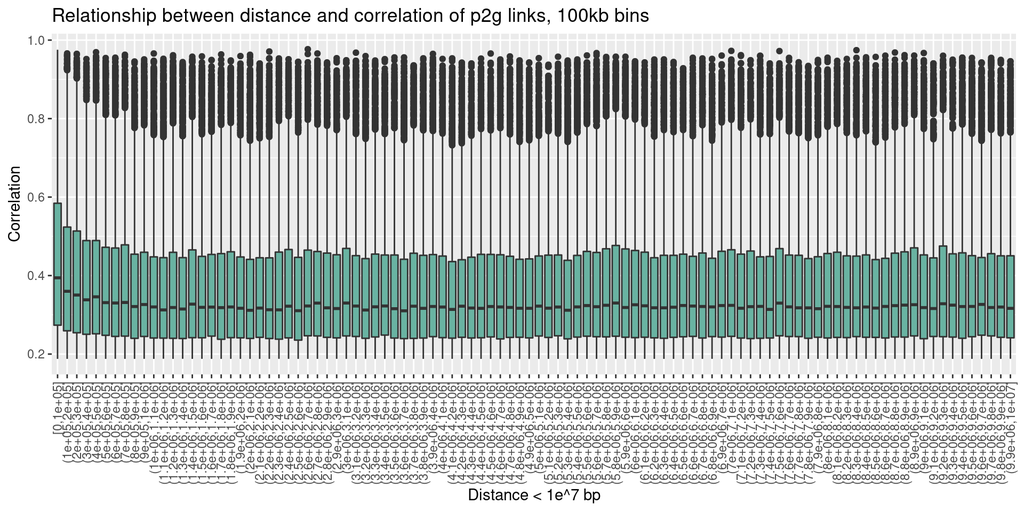

```r
p2g_join %>%
  mutate(bin=cut_width(distance, width=100000, boundary=0)) %>%
  filter(distance < 10000000) %>%
  ggplot() +
  geom_boxplot(aes(x = bin, y = Correlation), fill="#69b3a2") +
  labs(title = "Relationship between distance and correlation of p2g links, 100kb bins",
       x = "Distance < 1e^7 bp", y = "Correlation") +
  theme(axis.text.x = element_text(angle = 90, vjust = 0.5, hjust=1))
```

[figure not shown]

```r
p1 <- p2g_join %>%
  mutate(bin=cut_width(distance, width=100000, boundary=0)) %>%
  filter(distance < 10000000 & Correlation > 0.5) %>%
  ggplot() +
  geom_boxplot(aes(x = bin, y = Correlation), fill="#69b3a2") +
  labs(title = "Relationship between distance and correlation of p2g links, 100kb bins",
       x = "Distance < 1e^7 bp", y = "Correlation > 0.5") +
  theme(axis.text.x = element_text(angle = 90, vjust = 0.5, hjust=1))

p2 <- p2g_join %>%
  mutate(bin=cut_width(distance, width=100000, boundary=0)) %>%
  filter(distance < 10000000 & Correlation > 0.8) %>%
  ggplot() +
  geom_boxplot(aes(x = bin, y = Correlation), fill="#69b3a2") +
  labs(title = "Relationship between distance and correlation of p2g links, 100kb bins",
       x = "Distance < 1e^7 bp", y = "Correlation > 0.8") +
  theme(axis.text.x = element_text(angle = 90, vjust = 0.5, hjust=1))

p3 <- p2g_join %>%
  mutate(bin=cut_width(distance, width=100000, boundary=0)) %>%
  filter(distance < 10000000 & Correlation < 0.5) %>%
  ggplot() +
  geom_boxplot(aes(x = bin, y = Correlation), fill="#69b3a2") +
  labs(title = "Relationship between distance and correlation of p2g links, 100kb bins",
       x = "Distance < 1e^7 bp", y = "Correlation < 0.5") + theme(axis.text.x = element_text(angle = 90, vjust = 0.5, hjust=1))



p4 <- p2g_join %>%
  mutate(bin=cut_width(distance, width=1000, boundary=0)) %>%
  filter(distance < 100000 & Correlation > 0.5) %>%
  ggplot() +
  geom_boxplot(aes(x = bin, y = Correlation), fill="#69b3a2") +
  labs(title = "Relationship between distance and correlation of p2g links, 1kb bins",
       x = "Distance < 100kb", y = "Correlation") + theme(axis.text.x = element_text(angle = 90, vjust = 0.5, hjust=1))


cowplot::plot_grid(p1, p2, p3, p4, ncol = 2)
```

### Gene windows & distance weights

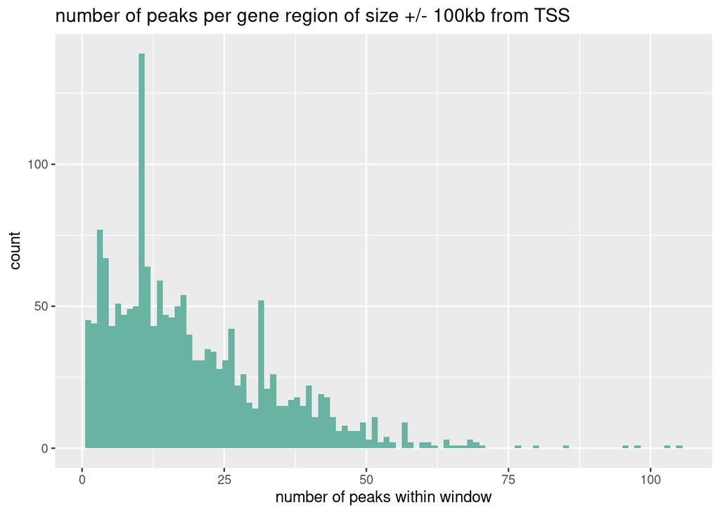

```r
# DISTANCE WEIGHT MATRIX + GENE WINDOW

# Create Gene window
geneRegions <- gene_anno
geneRegions$geneStart <- start(resize(geneRegions, 1, "start"))
geneRegions$geneEnd <- start(resize(geneRegions, 1, "end"))
geneRegions <- resize(geneRegions, 1, "start")
# extend the gene window +/-100,000 bp up- and downstream
extendedGeneRegion <- (suppressWarnings(extendGR(geneRegions,
                                                         upstream = 100000,
                                                         downstream = 100000)))

# find overlapping peaks and gene window in chromosome-aware fashion
tmp <- suppressWarnings(findOverlaps(extendedGeneRegion, (pos_atac_granges)))

print(paste0("Out of ", subjectLength(tmp), " peaks only ",
             length(unique(subjectHits(tmp))), " peaks are found within gene window of 200kb."))
## [1] "Out of 134072 peaks only 27877 peaks are found within gene window of 200kb."


### some plots
tmp %>% as.data.frame() %>%
       group_by(queryHits) %>% # gene region
       summarize(n = n()) %>% # get number of peaks overlapping with a gene region
       ggplot() + geom_histogram(aes(x = n), bins = 100, fill="#69b3a2") +
       labs(title = "number of peaks per gene region of size +/- 100kb from TSS",
           x = "number of peaks within window",)
```

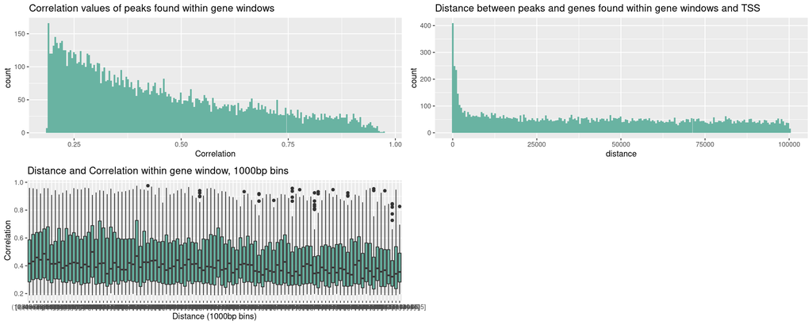

```r
# create a dataframe of all peaks which overlap their corresponding gene window
peaks_in_gene_window <- data.frame(gene = geneRegions[queryHits(tmp)]$gene,
           peak = pos_atac_granges[subjectHits(tmp)]$chr_idx) %>%
  unite(peak_gene_window, gene, peak, sep = "#", remove = FALSE)

# filter the p2g link dataframe for only peaks which are within a gene window
corr_window <- p2g_join %>%
  unite(peak_gene_window, gene, chr_idx, sep = "#", remove = FALSE) %>%
  filter(peak_gene_window %in% peaks_in_gene_window$peak_gene_window)


### PLOTS

p1 <- corr_window %>%
  ggplot() +
  geom_histogram(aes(x = Correlation), bins = 200, fill = "#69b3a2") +
  labs(title = "Correlation values of peaks found within gene windows")

p2 <- corr_window %>%
  ggplot() +
  geom_histogram(aes(x = distance), bins = 200, fill = "#69b3a2") +
  labs(title = "Distance between peaks and genes found within gene windows and TSS")

p3 <- corr_window %>%
  mutate(bin = cut_width(distance, width=1000, boundary=0)) %>%
  ggplot() +
  geom_boxplot(aes(x = bin, y = Correlation), fill = "#69b3a2") +
  labs(title = "Distance and Correlation within gene window, 1000bp bins",
       x = "Distance (1000bp bins)")
cowplot::plot_grid(p1, p2, p3, ncol = 2)
```

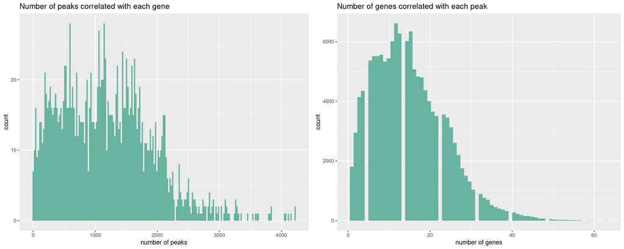

```r
p1 <- ggplot() +
  geom_histogram(aes(x = rowSums(p2g_mat > 0)), bins = 200, fill = "#69b3a2") +
  labs(title = "Number of peaks correlated with each gene", x = "number of peaks")

p2 <- ggplot() +
  geom_histogram(aes(x = colSums(p2g_mat > 0)), bins = 70, fill = "#69b3a2") +
  labs(title = "Number of genes correlated with each peak", x = "number of genes")

cowplot::plot_grid(p1, p2, ncol = 2)
```

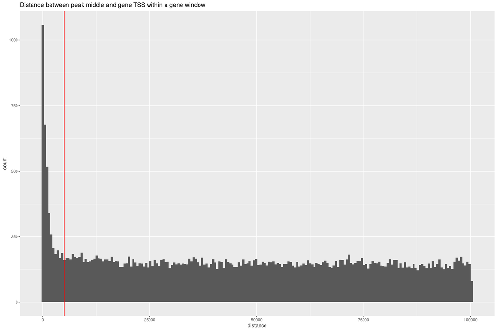

```r
# get distance between peak middle and gene TSS
# make a copy
peak_middle_region <- pos_atac_granges
# add the half width to the start of each peak
start(peak_middle_region) = start(peak_middle_region) +
  floor(width(peak_middle_region) / 2)
# resize the ranges so we only have the middle of each peak
peak_middle_region <- resize(peak_middle_region, 1, "start")

# compute the distances between peak middle and gene TSS of all peaks which
# overlap with a gene window
distance <- distance(ranges(geneRegions)[queryHits(tmp)],
              ranges(resize(peak_middle_region, width = 1))[subjectHits(tmp)])


### PLOT
ggplot() + geom_histogram(aes(x = distance), bins = 200) +
  labs(title = "Distance between peak middle and gene TSS within a gene window") +
  geom_vline(xintercept = 5000, color = "red")
```

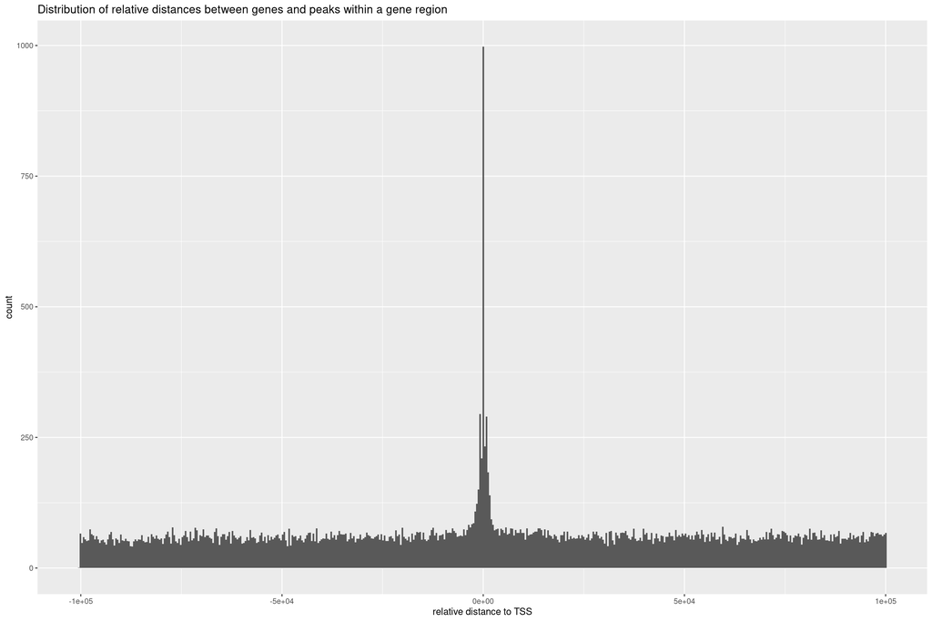

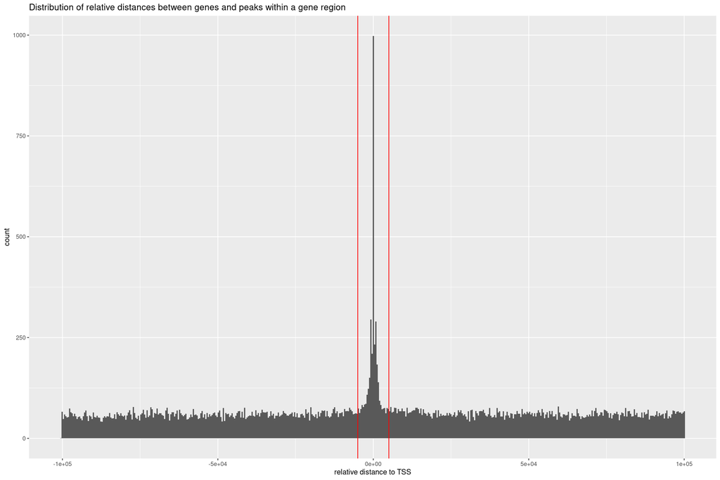

```r
isMinus <- BiocGenerics::which(strand(geneRegions) == "-")
# subtract the gene start coordinate from the tile start coordinate -> relative distances
signDist <- sign(start(peak_middle_region)[subjectHits(tmp)] -
                   start(resize(geneRegions,1,"start"))[queryHits(tmp)])
# convert the direction of distance for all distances corresponding to the negative strand
signDist[isMinus] <- signDist[isMinus] * -1


distance <- distance * signDist



#### PLOT
print(ggplot() + geom_histogram(aes(x = distance), bins = 500) +
  labs(title = "Distribution of relative distances between genes and peaks within a gene region",
       x = "relative distance to TSS")) +
  geom_vline(xintercept = c(5000, -5000), color = "red")
```

Since the effect of the distance weight decay seems to be very big, I tried different decay rates to see if higher decay rates means that more peaks are contributing to the gene activity score. In the plots below all peaks are plotted, regardless of whether they are within a gene window or not.

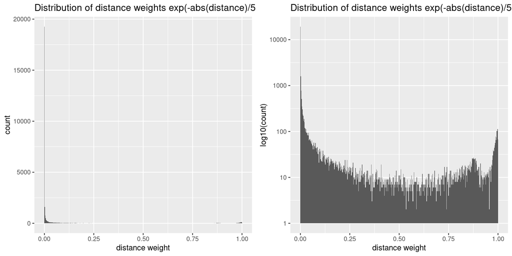

```
## [1] "There are 106195 which only get zero distance weights with genes when using exp(-abs(distance)/5000) which is the number of peaks not found in a gene window of size 200kb."
## Warning: Transformation introduced infinite values in continuous y-axis
## Warning: Removed 118 rows containing missing values (geom_bar).
```

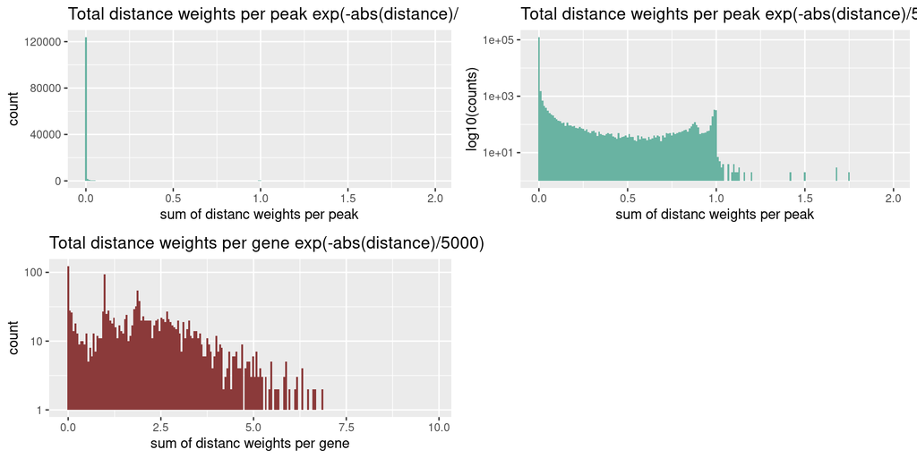

```
## [1] "There are 133646 peaks out of 134072 which only have zero correlations with genes after weighting by distance when using exp(-abs(distance)/5000)"
## [1] "There are 1606 genes out of 1706 which only have zero correlations with peaks after weighting by distance when using exp(-abs(distance)/5000)"
## [1] "The peak-to-gene matrix weighted by distance between peaks and genes using the model exp(-abs(distance)/5000)has dimensions1706x134072"
## Warning: Transformation introduced infinite values in continuous y-axis
## Warning: Removed 179 rows containing missing values (geom_bar).
```

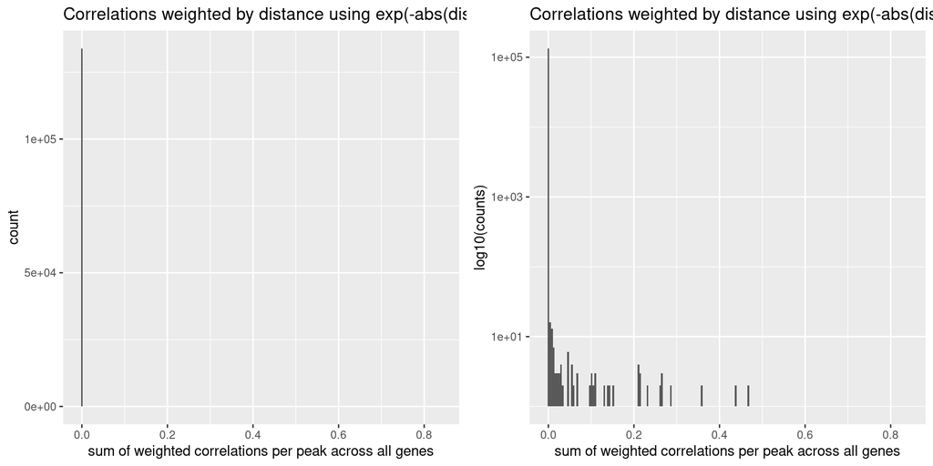

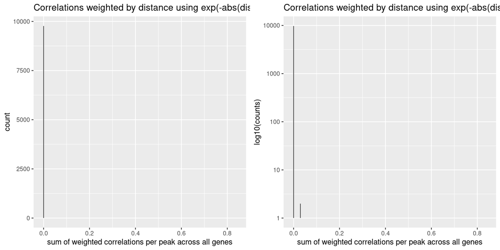

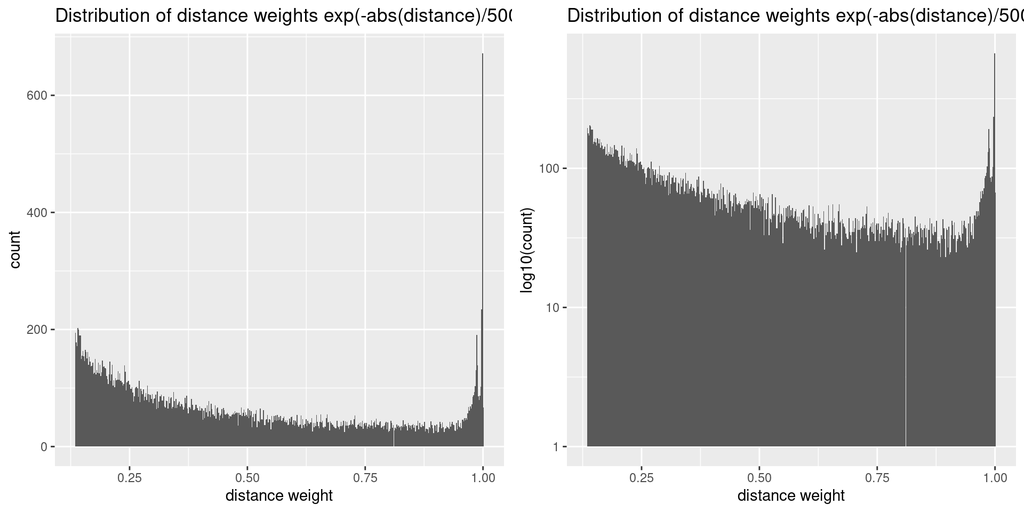

```
## [1] "There are 106195 which only get zero distance weights with genes when using exp(-abs(distance)/50000) which is the number of peaks not found in a gene window of size 200kb."
## Warning: Transformation introduced infinite values in continuous y-axis
## Warning: Removed 90 rows containing missing values (geom_bar).
```

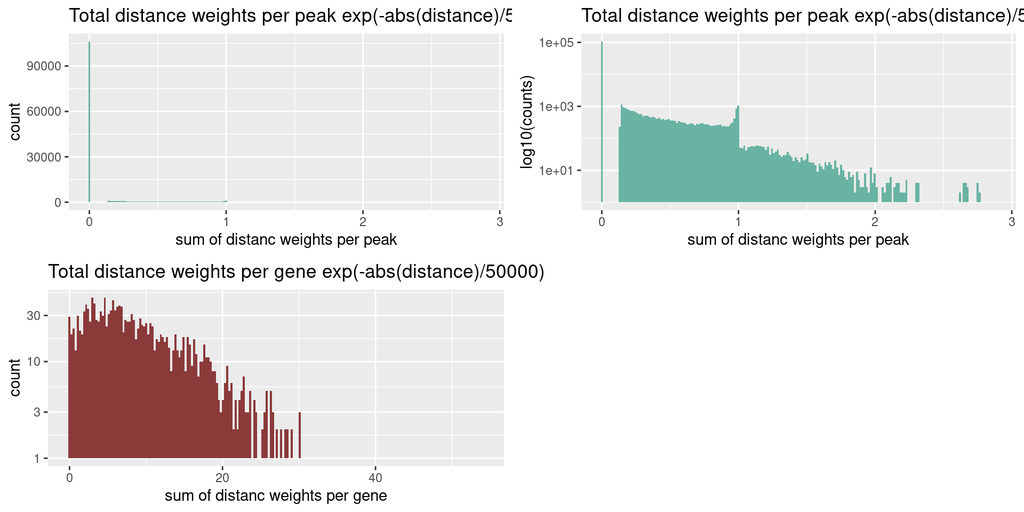

```
## [1] "There are 133646 peaks out of 134072 which only have zero correlations with genes after weighting by distance when using exp(-abs(distance)/50000)"
## [1] "There are 1606 genes out of 1706 which only have zero correlations with peaks after weighting by distance when using exp(-abs(distance)/50000)"
## [1] "The peak-to-gene matrix weighted by distance between peaks and genes using the model exp(-abs(distance)/50000)has dimensions1706x134072"
## Warning: Transformation introduced infinite values in continuous y-axis
## Warning: Removed 159 rows containing missing values (geom_bar).
```

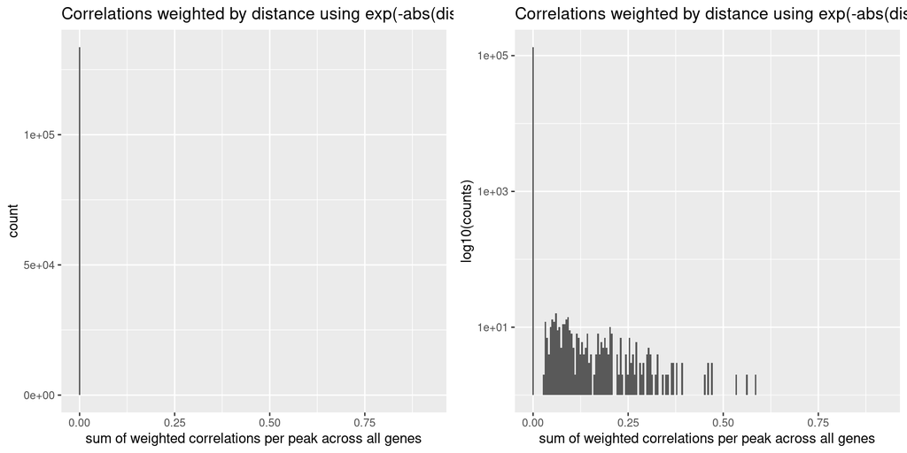

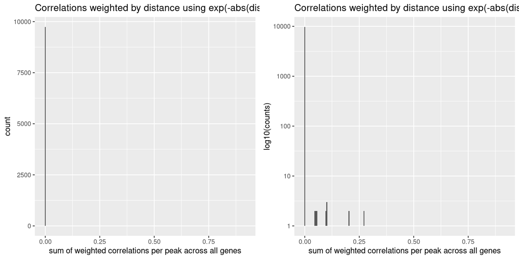

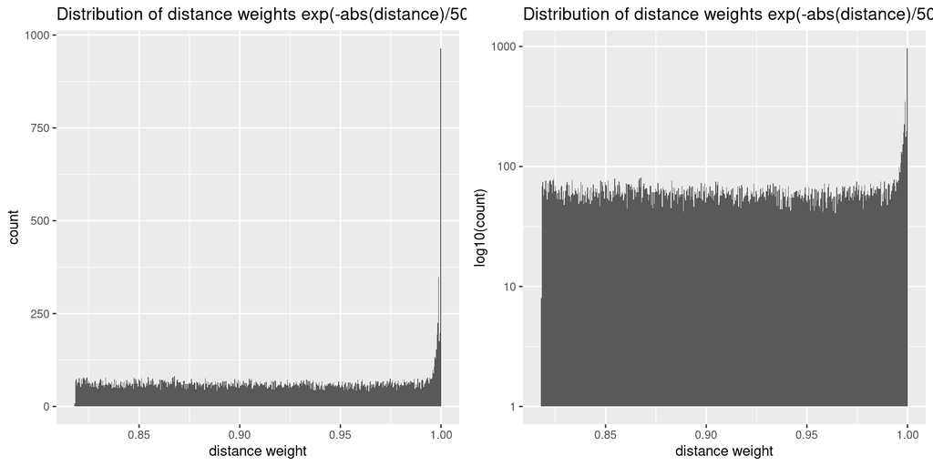

```
## [1] "There are 106195 which only get zero distance weights with genes when using exp(-abs(distance)/500000) which is the number of peaks not found in a gene window of size 200kb."
## Warning: Transformation introduced infinite values in continuous y-axis
## Warning: Removed 87 rows containing missing values (geom_bar).
```

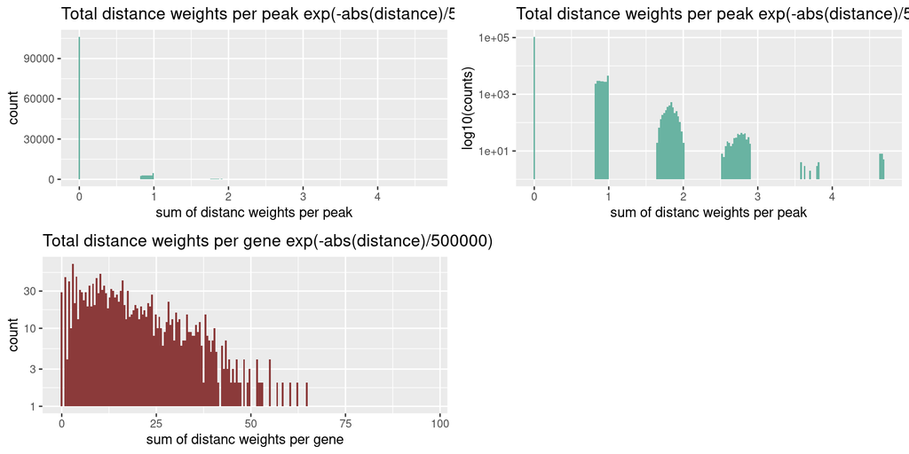

```
## [1] "There are 133646 peaks out of 134072 which only have zero correlations with genes after weighting by distance when using exp(-abs(distance)/500000)"
## [1] "There are 1606 genes out of 1706 which only have zero correlations with peaks after weighting by distance when using exp(-abs(distance)/500000)"
## [1] "The peak-to-gene matrix weighted by distance between peaks and genes using the model exp(-abs(distance)/500000)has dimensions1706x134072"
## Warning: Transformation introduced infinite values in continuous y-axis
## Warning: Removed 161 rows containing missing values (geom_bar).
```

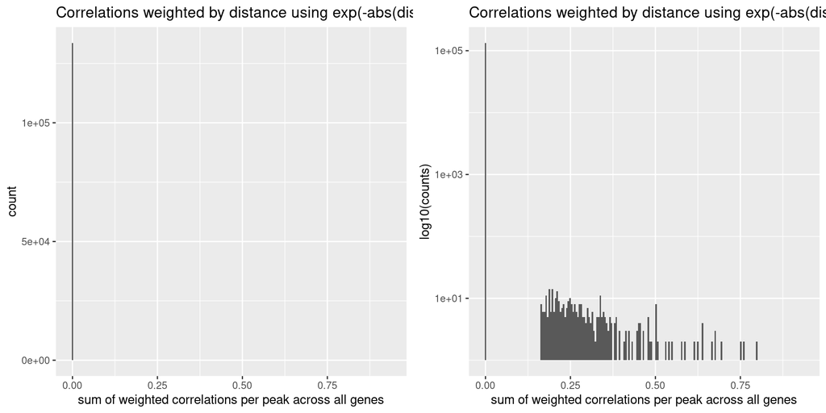

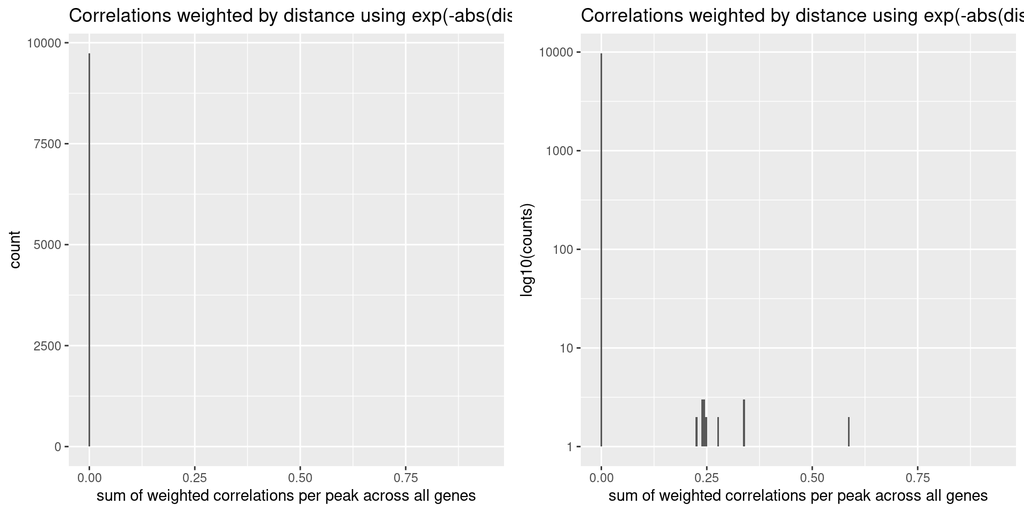

[4 more figures not shown]

```r
### Try different distance weight decay rates!
model_list <- c("exp(-abs(distance)/5000)", "exp(-abs(distance)/50000)",
                "exp(-abs(distance)/500000)", "exp(-abs(distance)/5000000)")

for (model in model_list){
  #Evaluate  Input Model -> compute distance weights
  distance_weights <- eval(parse(text=model))

  ### PLOTS
  p1 <- (ggplot() + geom_histogram(aes(x = distance_weights), bins = 500) +
    labs(title = paste0("Distribution of distance weights ", model),
         x = "distance weight"))
  p2 <- (ggplot() + geom_histogram(aes(x = distance_weights), bins = 500) +
    labs(title = paste0("Distribution of distance weights ", model),
         x = "distance weight", y = "log10(count)") +
      scale_y_log10())
  print(cowplot::plot_grid(p1, p2, ncol = 2))

  #distance <- distance *5

  #Creating Sparse Matrix
  weights_mat <- Matrix::sparseMatrix(
    i = queryHits(tmp),
    j = subjectHits(tmp),
    x = distance_weights,
    dims = c(length(geneRegions), ncol(p2g_mat))
  )

  ### PLOTS
  p1 <- ggplot() + geom_histogram(aes(x = colSums(weights_mat)),
                                  fill = "#69b3a2", bins = 200) +
    labs(title = paste0("Total distance weights per peak ", model),
         x = "sum of distanc weights per peak")

  p2 <- ggplot() + geom_histogram(aes(x = colSums(weights_mat)),
                                  bins = 200, fill = "#69b3a2") +
    scale_y_log10() +
    labs(title = paste0("Total distance weights per peak ", model),
         x = "sum of distanc weights per peak", y = "log10(counts)")

  p3 <- ggplot() +
    geom_histogram(aes(x = rowSums(weights_mat)),
                                  bins = 200, fill = "indianred4") +
    scale_y_log10() +
    labs(title = paste0("Total distance weights per gene ", model),
         x = "sum of distanc weights per gene")#, y = "log10(counts)")
  print(cowplot::plot_grid(p1, p2, p3, ncol = 2))


  print(paste0("There are ", length(which(colSums(weights_mat) == 0)), " which only get zero distance weights with genes when using ", model, " which is the number of peaks not found in a gene window of size 200kb."))




  #Calculate weighted p2g links
  weighted_p2g_mat <- weights_mat * p2g_mat


  ### PLOTS
  p1 <- ggplot() + geom_histogram(aes(x = colSums(weighted_p2g_mat)), bins = 200) +
    labs(title = paste0("Correlations weighted by distance using ", model),
         x = "sum of weighted correlations per peak across all genes")
  p2 <- ggplot() + geom_histogram(aes(x = colSums(weighted_p2g_mat)), bins = 200) +
  labs(title = paste0("Correlations weighted by distance using ", model),
       x = "sum of weighted correlations per peak across all genes",
       y = "log10(counts)") + scale_y_log10()

  print(cowplot::plot_grid(p1, p2, ncol = 2))

  print(paste0("There are ", length(which(colSums(weighted_p2g_mat) == 0)), " peaks out of ", dim(p2g_mat)[[2]], " which only have zero correlations with genes after weighting by distance when using ", model))

  print(paste0("There are ", length(which(rowSums(weighted_p2g_mat) == 0)), " genes out of ", dim(p2g_mat)[[1]], " which only have zero correlations with peaks after weighting by distance when using ", model))

  print(paste0("The peak-to-gene matrix weighted by distance between peaks and genes using the model ", model, "has dimensions", dim(weighted_p2g_mat)[[1]],
               "x", dim(weighted_p2g_mat)[[2]]))

  # Filter the weighted_p2g_mat to contain only peaks which are within the gene window
  weighted_filt_p2g <- weighted_p2g_mat[rownames(weighted_p2g_mat) %in% corr_window$gene,
                                        colnames(weighted_p2g_mat) %in% corr_window$chr_idx]

    ### PLOTS
  p1 <- ggplot() + geom_histogram(aes(x = colSums(weighted_filt_p2g)), bins = 200) +
    labs(title = paste0("Correlations weighted by distance using ", model),
         x = "sum of weighted correlations per peak across all genes")
  p2 <- ggplot() + geom_histogram(aes(x = colSums(weighted_filt_p2g)), bins = 200) +
  labs(title = paste0("Correlations weighted by distance using ", model),
       x = "sum of weighted correlations per peak across all genes",
       y = "log10(counts)") + scale_y_log10()

  print(cowplot::plot_grid(p1, p2, ncol = 2))



  #print(paste0("The peak-to-gene matrix weighted by distance between peaks and genes using the model ", model, " has dimensions ", dim(weighted_p2g_mat)[[1]], " x ", dim(weighted_p2g_mat[[2]])))
}
## Warning: Transformation introduced infinite values in continuous y-axis
## Warning: Removed 53 rows containing missing values (geom_bar).
## Warning: Transformation introduced infinite values in continuous y-axis
## Warning: Removed 56 rows containing missing values (geom_bar).
```

```r
#Calculate Gene Scores
# weighted_p2g_mat <- tmp * p2g_mat
#
# p1 <- ggplot() + geom_histogram(aes(x = colSums(p2g_mat)), bins = 200) +
#   labs(x = "sum of correlations per peak across all genes")
# print(p1)
#
# print(paste(length(which(rowSums(weighted_p2g_mat) == 0)), "genes have only zero correlation values, so we will remove them."))
# subset <- weighted_p2g_mat[which(rowSums(weighted_p2g_mat) != 0), ]
# print(paste0("We are left with ", dim(weighted_p2g_mat)[1], " genes"))
# subset1 <- weighted_p2g_mat[,which(colSums(weighted_p2g_mat)!= 0)]
```

### Gene windows & no distance weights

There are only 10,721 peak-to-gene links which are within gene windows, but 21,027,730 links on the entire chromosome.

```
corr_window$ColIndex <- match(corr_window$chr_idx, unique(corr_window$chr_idx))
corr_window$RowIndex <- match(corr_window$gene, unique(corr_window$gene))

p2g_links_gene_window <- Matrix::sparseMatrix(
    i = corr_window$RowIndex,
    j = corr_window$ColIndex,
    x = corr_window$Correlation,
    dims = c(length(geneRegions), ncol(p2g_mat)),
    dimnames = list(rownames(p2g_mat),colnames(p2g_mat))
    # dims = c(length(unique(corr_window$gene)),
    #          length(unique(corr_window$chr_idx)))
  )

print(paste0("The peak-to-gene links matrix, restricted to a +/- 100kb window around the TSS has dimensions ", split(dim(p2g_links_gene_window), 1)))

print(paste0("The maximum value is: ", max(p2g_links_gene_window), ", the minum value is: ", min(p2g_links_gene_window) ))



p2g_links_gene_window <- p2g_links_gene_window[which(rowSums(p2g_links_gene_window) != 0), ]
# Compute gene activity scores
weighted_scores <- gene_activity_scores(peak_mat, p2g_links_gene_window)
dim(p2g_links_gene_window)



#save as anndata object for further analysis in python
sce <- SingleCellExperiment(list(gene_window_scores=weighted_scores),
                          rowData = as.data.frame(rownames(weighted_scores)),
                          colData = as.data.frame(colnames(weighted_scores)))

writeH5AD(sce, paste0("/omics/groups/OE0533/internal/katharina/scDoRI/gastrulation_data/jupyter_notebooks/p2g_gene_activity_scores/gene_window_scores", X_name = "gene_window_scores"))

p1 <- ggplot() + geom_histogram(aes(x = colSums(p2g_links_gene_window)),
                                bins = 200, fill = "#69b3a2") +
  labs(title = "Correlations within gene windwos",
       x = "sum of correlations per peak across all genes")
p2 <- ggplot() + geom_histogram(aes(x = colSums(p2g_links_gene_window)),
                                bins = 200, fill = "#69b3a2") +
labs(title = "Correlations within gene windwos",
     x = "sum of correlations per peak across all genes",
     y = "log10(counts)") + scale_y_log10()

#print(cowplot::plot_grid(p1, p2, ncol = 2))


p3 <- ggplot() + geom_histogram(aes(x = colSums(hvg_p2g)),
                                fill = "indianred4", bins = 200) +
  labs(title = "Correlations",
       x = "sum of correlations per peak across all genes")
p4 <- ggplot() + geom_histogram(aes(x = colSums(hvg_p2g)),
                                fill = "indianred4", bins = 200) +
labs(title = "Correlations",
     x = "sum of correlations per peak across all genes",
     y = "log10(counts)") + scale_y_log10()

print(cowplot::plot_grid(p1, p2, p3, p4, ncol = 2))
```

```
links <- hvg_p2g[which(rowSums(hvg_p2g) != 0), ]


test <- gene_activity_scores(peak_mat, links)


#save as anndata object for further analysis in python
sce <- SingleCellExperiment(list(test=test),
                          rowData = as.data.frame(rownames(test)),
                          colData = as.data.frame(colnames(test)))

writeH5AD(sce, paste0("/omics/groups/OE0533/internal/katharina/scDoRI/gastrulation_data/jupyter_notebooks/p2g_gene_activity_scores/test", X_name = "test"))
```

```
model_list = c("exp(-distance/5000000)", "exp(-distance/50000000)")
weight_list = c("5000000", "50000000")

for (i in model_list){
  weight = gsub(".*?([0-9]+).*",  "\\1", i)
  print(weight)
  distanc_weighted_gene_activity_scores(hvg_p2g, geneModel = i,
                                        weight = weight,
                                        peak_mat, p2g, p2g_original, proj)
}
```

```
proj <- loadArchRProject("12_Ricards_peaks_ChromVar/")
atac_granges <- metadata(p2g_original)[[1]]
#rna_granges <- metadata(p2g_original)[[2]]
gene_expr <- getMatrixFromProject(proj, useMatrix = "GeneExpressionMatrix")
gene_anno <- rowData(gene_expr)


# create gene annotations with start coordinate of each gene
gene_anno <- gene_anno %>% as.data.frame() %>%
  filter(name %in% rownames(hvg_p2g)) %>%
  mutate(strand = ifelse(strand == 1, "+", "-")) %>%
  mutate(start_coord = ifelse(strand == "+", start, end)) %>%
  rename(gene = name) %>%
  GRanges()



# subset atac granges
pos_atac_granges <- atac_granges  %>%
  as.data.frame() %>%
  group_by(seqnames) %>%
  mutate(idx = seq_along(seqnames)) %>%
  ungroup %>%
  tidyr::unite(chr_idx, seqnames, idx, remove = FALSE, sep = "_") %>%
  filter(chr_idx %in% colnames(hvg_p2g)) %>%
  mutate(middle = start + 300) %>%
  GRanges()

#TODO: Filter for genes!
p2g_filt <- p2g %>% filter(gene %in% rownames(hvg_p2g))



p2g_join <- left_join(p2g_filt, as.data.frame(pos_atac_granges), by = "chr_idx")
p2g_join <- left_join(p2g_join, as.data.frame(gene_anno), by = "gene", suffix = c(".atac", ".rna"))

# p2g_join = inner_join(p2g, as.data.frame(pos_atac_granges), by = "chr_idx", all = TRUE)#, suffix = c(".p2g", ".rna"))
# p2g_join = inner_join(p2g_join, as.data.frame(gene_anno), by = "gene", suffix = c(".atac", ".rna"), all = TRUE)


```

[output cut: 32 more lines]

```
                                       unique(p2g_join$chr_idx)))

p2g_dw[1:10, 1:5]
dim(p2g_dw)


# filter p2gmat of highly variable genes. Why do we lose some peaks?
p2g_mat <- hvg_p2g[, colnames(hvg_p2g) %in% colnames(p2g_dw)]

# # save p2g_dw
# sce <- SingleCellExperiment(list(p2g_dw=p2g_dw),
#                             rowData = as.data.frame(rownames(p2g_dw)),
#                             colData = as.data.frame(colnames(p2g_dw)))
#
# writeH5AD(sce, "/omics/groups/OE0533/internal/katharina/scDoRI/gastrulation_data/p2g_links_archr/p2g_weight_matrix", X_name = "p2g_dw")
```

**RNA Granges**

```
rna_granges
```

**ATAC Granges**

```
atac_granges
```

## Compute gene activity scores including the distanc weights

We do element-wise multiplication of the peak-to-gene matrix with the distance weight matrix. Then we use the product as input for the function.

```
weighted_p2g_mat <- p2g_mat * p2g_dw

# # save p2g_dw
# sce <- SingleCellExperiment(list(weighted_p2g_mat=weighted_p2g_mat),
#                             rowData = as.data.frame(rownames(weighted_p2g_mat)),
#                             colData = as.data.frame(colnames(weighted_p2g_mat)))
#
# writeH5AD(sce, "/omics/groups/OE0533/internal/katharina/scDoRI/gastrulation_data/p2g_links_archr/weighted_p2g_mat", X_name = "weighted_p2g_mat")
```

**Lets have a look at the three matrices**

Peak-to-gene matrix

```
p2g_mat[1:10,1:5]
```

Distance weight matrix:

```
p2g_dw[1:10, 1:5]
```

Weighted p2g matrix:

```
weighted_p2g_mat[1:10, 1:5]
```

Weighted Gene activity scores

```
#p2g_mat <- weighted_p2g_mat

# Since there are some genes where all links to peaks are zero, we will have to remove those before continuing with our computations
print(paste(length(which(rowSums(weighted_p2g_mat) == 0)), "genes have only zero correlation values, so we will remove them."))
weighted_p2g_mat <- weighted_p2g_mat[which(rowSums(weighted_p2g_mat) != 0), ]
print(paste0("We are left with ", dim(weighted_p2g_mat)[1], " genes"))

weighted_scores <- gene_activity_scores(peak_mat, weighted_p2g_mat)


# peak_mat_subset <- peak_mat[colnames(p2g_mat), ]
# # normalize the p2g matrix by the total number of peaks linked to each gene
# p2g_mat <- p2g_mat / rowSums(p2g_mat)
# # Now we can compute a weighted sum of peak2gene correlations for each
# # peak and gene
# scores <- p2g_mat %*% peak_mat_subset
# # create a dataframe for computing the linear model
# linear_model_df <- data.frame(cell = colnames(scores),
#                              total_activity = colSums(scores),
#                              total_sites = colSums(peak_mat_subset))
# # compute a linear model
# activity_model <- stats::lm(log(total_activity) ~ log(total_sites),
#                           data = linear_model_df)
# # extract the fitted model
# linear_model_df$fitted_curve <- exp(as.vector(predict(activity_model,
#                                                        type = "response")))
# # compute size factors from fitted model
# size_factors <- mean(linear_model_df$fitted_curve) / linear_model_df$fitted_curve
# # create diagonal matrix containing the size factors
# size_factors_mat <- Matrix::Diagonal(x = size_factors)
# row.names(size_factors_mat) <- linear_model_df$cell
# # normalize by library depth size factors
# norm_scores <- Matrix::t(size_factors_mat %*% Matrix::t(scores))
# # exponentiate, because RNA counts are log-normally distributed
# norm_scores@x <- pmin(1e9, exp(norm_scores@x) - 1)
#
# # free some memory
# rm(peak_mat_subset)
# rm(activity_model)
# rm(scores)
# gc(reset = TRUE)
#
# # scale with total activity scores again
# scale_factors <- Matrix::Diagonal(x = 1/Matrix::colSums(norm_scores))
#
# final_scores <- Matrix::t(scale_factors %*% Matrix::t(norm_scores))
```

```
#save p2g_dw
sce <- SingleCellExperiment(list(final_scores=weighted_scores),
                            rowData = as.data.frame(rownames(weighted_scores)),
                            colData = as.data.frame(colnames(weighted_scores)))

writeH5AD(sce, "/omics/groups/OE0533/internal/katharina/scDoRI/gastrulation_data/jupyter_notebooks/p2g_gene_activity_scores/p2g_scores_dist_50000", X_name = "final_scores")
```

# Try shuffling genes before computing p2g correlations in ArchR

# Add Peak2Gene Links

```r
# Create a copy of the ArchR object
#saveArchRProject(proj, "12_Ricards_peaks_ChromVar_COPY/", load = FALSE)
#shuffle_proj <- loadArchRProject("12_Ricards_peaks_ChromVar_COPY/")
```

Shuffle the genes in the gene annotations of the gene expression matrix. Using these shuffled annotations compute the peak-to-gene links again. I checked the source code and they use the GRanges object from the gene expression matrix when computing peak-to-gene links and not the `getGeneAnnotations()`.

```
gene_expr <- getMatrixFromProject(proj, useMatrix = "GeneExpressionMatrix")
rowData(gene_expr) %>% head
gene_expr_new <- gene_expr
rownames(expr_mat) <- rowData(gene_expr)$name
expr_mat <- assays(gene_expr_new)[[1]]
gene_anno <- rowData(gene_expr_new)
gene_anno %>% head


# shuffle the chromosomes, making sure that a gene wil not end up on the
#chromosome it was originally on
gene_anno <- gene_anno %>% as.data.frame() %>%
  mutate(new_chrom = "NULL")

ctx <- table(gene_anno$seqnames)

for (chr in unique(gene_anno$seqnames)) {
  n <- sum(gene_anno$seqnames == chr)
  idx <- which(gene_anno$seqnames == chr)
  sample_from <- names(ctx)[names(ctx) != chr]
  gene_anno[idx, "new_chrom"] <- sample(x=sample_from, size=n, replace=TRUE,
                                        prob = ctx[sample_from] / sum(ctx[sample_from]))
}


# plot the chromosome proportions before and after shuffling
p1 <- gene_anno %>% ggplot() +
  geom_bar(aes(x = new_chrom))

p2 <- gene_anno %>% ggplot() +
  geom_bar(aes(x = seqnames))

cowplot::plot_grid(p1, p2, ncol = 1)

# save shuffled gene annotations and convert strands to +/- instead of 1/2
gene_anno_shuffled <- gene_anno %>%
  mutate(seqnames = new_chrom, new_chrom = NULL) %>%
  mutate(strand = ifelse(strand == 1, "+", "-"))




granges_shuffled <- makeGRangesFromDataFrame(gene_anno_shuffled)
mcols(granges_shuffled) <- gene_anno_shuffled$name

# For some reason only the metadata columns are shown when constructing a
# SummarizedExperiment
# We need rownames in the expression matrix of the SE object!
seRNA <- SummarizedExperiment(assays = list(counts = expr_mat),
                              rowRanges = granges_shuffled)


# add the shuffled gene expression SCE to the object
shuffle_proj <- addGeneExpressionMatrix(input = shuffle_proj, seRNA = seRNA, force = TRUE,
                                scaleTo = 10000)

# Lets hae a look at the shuffled gene expression
shuffled_gene_expr <- getMatrixFromProject(shuffle_proj, useMatrix = "GeneExpressionMatrix")

# And we can see that the gene names are different than before
rowData(shuffled_gene_expr) %>% head

shuffled_mat <- assays(shuffled_gene_expr)[[1]]
rownames(shuffled_mat) <- rowData(shuffled_gene_expr)$name

#saveArchRProject(shuffle_proj, "12_Ricards_peaks_ChromVar_COPY/", load = FALSE)
```

```
gene_anno <- getGeneAnnotation(shuffle_proj)
genes <- gene_anno %>% `$`(.,"genes") %>%
  as.data.frame() %>% mutate(new_chrom = "NULL")

ctx <- table(genes$seqnames)

for (chr in unique(genes$seqnames)) {
  n <- sum(genes$seqnames == chr)
  idx <- which(genes$seqnames == chr)
  sample_from <- names(ctx)[names(ctx) != chr]
  genes[idx, "new_chrom"] <- sample(x=sample_from, size=n, replace=TRUE,
                                        prob = ctx[sample_from] / sum(ctx[sample_from]))
}
p1 <- genes %>% ggplot() +
  geom_bar(aes(x = new_chrom))

p2 <- genes %>% ggplot() +
  geom_bar(aes(x = seqnames))

cowplot::plot_grid(p1, p2, ncol = 1)

genes <- genes %>% mutate(seqnames = new_chrom, new_chrom = NULL)

gene_anno$genes <- genes


geneSet <- ArchR:::.getFeatureDF(getArrowFiles(shuffle_proj), "GeneExpressionMatrix")
geneStart <- GRanges(geneSet$seqnames, IRanges(geneSet$start, width = 1), name = geneSet$name, idx = geneSet$idx)
```

Using the shuffled gene expression matrix where each gene is assigned to a wrong chromosome we compute peak2gene links again. Then, using these shuffled genes, we compute gene activity scores to see how they will differ.

```
shuffle_proj <- addPeak2GeneLinks(  ArchRProj = shuffle_proj,
  reducedDims  = "atac_LSI_100000",
  useMatrix = "GeneExpressionMatrix",
  maxDist = 400000000,
  verbose = FALSE
  )
```

```
p2g <- getPeak2GeneLinks(
  ArchRProj = shuffle_proj,
  corCutOff = -1,
  resolution = 1,
  FDRCutOff = 1e-04,
  varCutOffATAC = .25,
  varCutOffRNA = .25,
  returnLoops = FALSE
)
```

```
p1 <- p2g %>% as_tibble() %>% ggplot() +
  geom_histogram(aes(x = Correlation), bins = 100, fill = "blue",
                 color = "black", alpha = .6)
```

# Plot scores as UMAPs

```
proj <- loadArchRProject()
# create summarized experiment of the scRNA-seq
seRNA <- SummarizedExperiment(assays = list(counts=weighted_score),
                          colData = colnames(weighted_score),
                          rowRanges = granges)
seRNA


# add RNA gene expression matrix to the ArchR object
# we need to set scaleTo to one, since it is 1000 by default!
proj <- addGeneExpressionMatrix(input = proj, seRNA = seRNA, force = TRUE,
                                scaleTo = 1)


# save the ArchR object with the added gene expression matrix
#saveArchRProject(proj, outputDirectory = "13_added_gene_score_from_p2g/", load = FALSE)

#saveArchRProject(proj, outputDirectory = "15_gene_scores_from_p2g_as_gene_expr_matrix")
```

```
proj <- loadArchRProject("15_gene_scores_from_p2g_as_gene_expr_matrix/")

marker_genes <- c("Lamb1",  "Sparc", "Elf5", "Ascl2", "Tfap2c", "Ttr",
                  "Apoa2", "Apoe", "Cystm1", "Emb", "Spink1",  "Krt19",
                  "Dkk1", "Grhl3", "Trp63", "Grhl2",  "Pax6", "Pax2",
                  "En1", "Foxd3", "Tfap2a", "Pax3", "Sox9",
                  "Six3", "Hesx1", "Irx3", "Sox2", "Hoxb9", "Cdx4",
                  "Hes3", "Hba-a2", "Hba-a1",  "Hbb-bh1", "Gata1", "Cited4",
                   "Cdh5", "Pecam1", "Anxa5", "Etv2", "Igf2",
                  "Krt8", "Krt18", "Pmp22", "Ahnak", "Bmp4", "Tbx4", "Hoxa11",
                  "Hoxa10", "Tnnt2", "Myl4",  "Myl7", "Acta2",
                  "Smarcd3", "Tcf21", "Tbx6", "Dll1", "Aldh1a2", "Tcf15",
                  "Meox1", "Tbx1", "Gbx2", "Cdx1", "Hoxb1", "Hes7", "Osr1",
                  "Mesp2", "Lefty2", "Mesp1", "Cer1",  "Chrd", "T",
                  "Foxa2", "Pax7", "Fgf8", "Lhx1", "Gsc", "Mixl1", "Otx2", "Hhex",
                   "Ifitm3", "Nkx1-2", "Eomes", "Nanog", "Utf1",
                  "Epcam", "Pou5f1")
```

# Have a look at the negative correlation values

```
proj <- addPeak2GeneLinks(ArchRProj = proj,
  reducedDims  = "atac_LSI_100000",
  useMatrix = "GeneExpressionMatrix",
  maxDist = 400000000,
  verbose = FALSE,
  )

p2g <- getPeak2GeneLinks(
  ArchRProj = proj,
  corCutOff = -1,
  resolution = 1,
  FDRCutOff = 1e-04,
  varCutOffATAC = .25,
  varCutOffRNA = .25,
  returnLoops = FALSE
)

saveRDS(p2g, "all_peak2gene_links_df.rds")
```

[output not shown]

# Min-max scaling instead of z-scores

```r
# How it works
# use the pg2 link matrix containing only hvg from above
test <- hvg_p2g[1:10, 1:5]
max_val <- apply(test, 2, max)
min_val <- apply(test, 2, min)
norm_test <- t(t(test) / max_val)
norm_test[1, ] / max_val
##   chr1_1   chr1_2   chr1_6   chr1_7   chr1_9
## 2.296601 1.515843 1.153019 1.221461 1.845814
norm_test[2, ] / max_val
## chr1_1 chr1_2 chr1_6 chr1_7 chr1_9
##      0      0      0      0      0
norm_test[3, ] / max_val
##    chr1_1    chr1_2    chr1_6    chr1_7    chr1_9
## 0.0000000 0.5863821 0.3188992 0.3483495 1.3629114
norm_test
## 10 x 5 sparse Matrix of class "dgCMatrix"
##                  chr1_1    chr1_2    chr1_6    chr1_7    chr1_9
## Xkr4          1.0000000 1.0000000 1.0000000 1.0000000 1.0000000
## Rp1           .         .         .         .         .
## Sntg1         .         0.3868357 0.2765776 0.2851909 0.7383798
## 1700034P13Rik 0.7725981 0.6659393 0.5840392 0.6600181 0.5683093
## Sgk3          .         .         .         .         .
## Cpa6          .         .         .         .         .
## Prex2         .         .         .         .         0.4703112
## A830018L16Rik 0.4858549 0.5530146 0.6697215 0.5760388 0.7410230
## Eya1          .         .         .         .         .
## Kcnb2         .         .         .         .         .
```

```
max_val <- apply(hvg_p2g, 2, max)
min_val <- apply(hvg_p2g, 2, min)
minmax_p2g <- t((t(hvg_p2g) - min_val) / (max_val - min_val))
print(paste0("After min-max normalization we get a minimum value of ", min(minmax_p2g), " and a maximum value of ", max(minmax_p2g), "."))
```

```r
# p2g$ColIndex <- match(p2g$idxATAC, unique(p2g$idxATAC))
# p2g$RowIndex <- match(p2g$idxRNA, unique(p2g$idxRNA))
#
# # create a sparse matrix with the correlation values
# p2g_mat_test <- sparseMatrix(i = p2g$RowIndex,
#                         j = p2g$ColIndex,
#                         x = p2g$Correlation,
#                         dims = c(length(unique(p2g$idxRNA)),
#                                  length(unique(p2g$idxATAC))))
#                         # dimnames = list(unique(p2g_idx$gene),
#                         #                 unique(p2g_idx$chr_idx)))

# colSums(data)/colSums(!!data)
#
# colSums(pos_peak_mat != 0)
#
# test = colSums(pos_peak_mat) /colSums(!!pos_peak_mat)
# ggplot() + geom_histogram(aes(x = colMeans(pos_peak_mat != 0)), bins = 100)
```